# Exploratory Data Analysis

I will make an exploratory data analysis about Airbnb listings in Madrid, Spain for the machine learning course using Madrid Airbnb Data from Kaggle.

## Housing problems

The starting point is the consideration that there is a huge problem with housing and tourism in Madrid: it is known that many private owners find more profitable and lucrative to rent out apartments to tourist than to locals (especially in the city center), and many estate agencies buy properties and convert them to tourist accommodations, too. All of which has the effect of reducing the offer, increasing the prices and pushing locals to other suburban neighbourhoods, leaving only tourists in the center.

To begin with, I looked at listings. I will import the libraries I will use, next import the data set listings.csv, clean the data set, and finally visualize the data frame with plots to find out relationships between the variables.

## Importing libraries

```python
import numpy as np
import pandas as pd
import matplotlib.pyplot as plt
import matplotlib.image as mpimg
%matplotlib inline
import seaborn as sns
from pandas_profiling import ProfileReport
import warnings
from scipy import stats
```

## Loading the data set

```python
listings = pd.read_csv('../data/raw/listings.csv', encoding='latin-1') #load the data frame listings.csv
```

```python
listings.head() #show me the first 10 rows or observations
```

|  | id | name | host_id | host_name | neighbourhood_group | neighbourhood | latitude | longitude | room_type | price | minimum_nights | number_of_reviews | last_review | reviews_per_month | calculated_host_listings_count | availability_365 |
| --- | --- | --- | --- | --- | --- | --- | --- | --- | --- | --- | --- | --- | --- | --- | --- | --- |
| 0 | 6369 | Rooftop terrace room with ensuite bathroom, Airc. | 13660 | Simon | Chamartín | Hispanoamérica | 40.45628 | -3.67763 | Private room | 70 | 1 | 65 | 2019-09-04 | 0.56 | 1 | 53 |
| 1 | 21853 | Bright and airy room | 83531 | Abdel | Latina | Cármenes | 40.40341 | -3.74084 | Private room | 17 | 4 | 33 | 2018-07-15 | 0.55 | 2 | 48 |
| 2 | 24805 | Gran Via Studio Madrid | 101471 | Iraido | Centro | Universidad | 40.42202 | -3.70395 | Entire home/apt | 80 | 5 | 2 | 2017-07-03 | 0.03 | 1 | 354 |
| 3 | 24836 | Select the Madrid more "cool". | 101653 | Tenty | Centro | Justicia | 40.41995 | -3.69764 | Entire home/apt | 115 | 3 | 64 | 2019-07-07 | 0.63 | 1 | 301 |
| 4 | 26825 | Single Room whith private Bathroom | 114340 | Agustina | Arganzuela | Legazpi | 40.38985 | -3.69011 | Private room | 25 | 2 | 136 | 2019-07-10 | 1.19 | 1 | 337 |

```python
listings['neighbourhood_group'].replace({"ChamartÃn": "Chamberi"}, inplace = True)
listings['neighbourhood'].replace({"HispanoamÃ©rica": "Hispanoamerica"}, inplace = True)
listings['neighbourhood'].replace({"CÃ¡rmenes": "Carmenes"}, inplace = True)
```

```python
listings.tail() #show me the last 10 rows or observations
```

|  | id | name | host_id | host_name | neighbourhood_group | neighbourhood | latitude | longitude | room_type | price | minimum_nights | number_of_reviews | last_review | reviews_per_month | calculated_host_listings_count | availability_365 |
| --- | --- | --- | --- | --- | --- | --- | --- | --- | --- | --- | --- | --- | --- | --- | --- | --- |
| 20832 | 38725567 | Acogedor piso de 2 Hab. Hospital La paz 4 Torres | 226958922 | Cristóbal | Chamberi | Castilla | 40.47847 | -3.68395 | Entire home/apt | 100 | 1 | 0 | NaN | NaN | 4 | 108 |
| 20833 | 38726351 | a 25-minutos del centro de Madrid near Subway | 178608863 | Rostyslav | Puente de Vallecas | Palomeras Sureste | 40.38533 | -3.63968 | Private room | 24 | 2 | 0 | NaN | NaN | 4 | 74 |
| 20834 | 38727654 | Apartamento Confortable a 300 m de la Gran Vía. | 182062359 | Jose Maciel | Centro | Universidad | 40.42182 | -3.70336 | Entire home/apt | 75 | 2 | 0 | NaN | NaN | 2 | 196 |
| 20835 | 38728727 | Estudio en pleno Lavapiés | 31425029 | Valeska | Centro | Embajadores | 40.40896 | -3.70107 | Entire home/apt | 45 | 2 | 0 | NaN | NaN | 1 | 104 |
| 20836 | 38730025 | Chueca y gran vía central | 6903368 | Miguel | Centro | Justicia | 40.41973 | -3.69666 | Private room | 75 | 1 | 0 | NaN | NaN | 5 | 268 |

```python
listings.columns # show me the columns names
```

```
Index(['id', 'name', 'host_id', 'host_name', 'neighbourhood_group',
       'neighbourhood', 'latitude', 'longitude', 'room_type', 'price',
       'minimum_nights', 'number_of_reviews', 'last_review',
       'reviews_per_month', 'calculated_host_listings_count',
       'availability_365'],
      dtype='object')
```

#### Print the Shape of the dataset

```python
listings.shape
```

```
(20837, 16)
```

#### Print the Datatype of the variables in the dataset

```python
listings.dtypes
```

```
id                                  int64
name                               object
host_id                             int64
host_name                          object
neighbourhood_group                object
neighbourhood                      object
latitude                          float64
longitude                         float64
room_type                          object
price                               int64
minimum_nights                      int64
number_of_reviews                   int64
last_review                        object
reviews_per_month                 float64
calculated_host_listings_count      int64
availability_365                    int64
dtype: object
```

```python
listings.info() ##info() function is used to get a concise summary of the dataframe
```

```
<class 'pandas.core.frame.DataFrame'>
RangeIndex: 20837 entries, 0 to 20836
Data columns (total 16 columns):
 #   Column                          Non-Null Count  Dtype
---  ------                          --------------  -----
 0   id                              20837 non-null  int64
 1   name                            20832 non-null  object
 2   host_id                         20837 non-null  int64
 3   host_name                       20822 non-null  object
 4   neighbourhood_group             20837 non-null  object
 5   neighbourhood                   20837 non-null  object
 6   latitude                        20837 non-null  float64
 7   longitude                       20837 non-null  float64
 8   room_type                       20837 non-null  object
 9   price                           20837 non-null  int64
 10  minimum_nights                  20837 non-null  int64
 11  number_of_reviews               20837 non-null  int64
 12  last_review                     16183 non-null  object
 13  reviews_per_month               16183 non-null  float64
 14  calculated_host_listings_count  20837 non-null  int64
 15  availability_365                20837 non-null  int64
dtypes: float64(3), int64(7), object(6)
memory usage: 2.5+ MB
```

## Cleaning the data set

#### Removing the Duplicates and NaN if any

```python
listings.duplicated().sum() ##It hasn't duplicates
```

```
0
```

```python
listings.isnull().sum() #sum of nulls per column
```

```
id                                   0
name                                 5
host_id                              0
host_name                           15
neighbourhood_group                  0
neighbourhood                        0
latitude                             0
longitude                            0
room_type                            0
price                                0
minimum_nights                       0
number_of_reviews                    0
last_review                       4654
reviews_per_month                 4654
calculated_host_listings_count       0
availability_365                     0
dtype: int64
```

```python
listings.dropna(how='any',inplace=True) #drop nulls
```

```python
listings.isnull().sum() #check the results
```

```
id                                0
name                              0
host_id                           0
host_name                         0
neighbourhood_group               0
neighbourhood                     0
latitude                          0
longitude                         0
room_type                         0
price                             0
minimum_nights                    0
number_of_reviews                 0
last_review                       0
reviews_per_month                 0
calculated_host_listings_count    0
availability_365                  0
dtype: int64
```

#### Drop unnecessary columns

```python
listings.drop(['name','host_name','last_review'], axis=1, inplace=True)
```

```python
listings.head() #check the status of the data set
```

|  | id | host_id | neighbourhood_group | neighbourhood | latitude | longitude | room_type | price | minimum_nights | number_of_reviews | reviews_per_month | calculated_host_listings_count | availability_365 |
| --- | --- | --- | --- | --- | --- | --- | --- | --- | --- | --- | --- | --- | --- |
| 0 | 6369 | 13660 | Chamberi | Hispanoamerica | 40.45628 | -3.67763 | Private room | 70 | 1 | 65 | 0.56 | 1 | 53 |
| 1 | 21853 | 83531 | Latina | Carmenes | 40.40341 | -3.74084 | Private room | 17 | 4 | 33 | 0.55 | 2 | 48 |
| 2 | 24805 | 101471 | Centro | Universidad | 40.42202 | -3.70395 | Entire home/apt | 80 | 5 | 2 | 0.03 | 1 | 354 |
| 3 | 24836 | 101653 | Centro | Justicia | 40.41995 | -3.69764 | Entire home/apt | 115 | 3 | 64 | 0.63 | 1 | 301 |
| 4 | 26825 | 114340 | Arganzuela | Legazpi | 40.38985 | -3.69011 | Private room | 25 | 2 | 136 | 1.19 | 1 | 337 |

## Visualize the data set

Plot all Neighbourhood Group

```python
listings['neighbourhood_group'].unique() # tell me the unique neighbourhood
```

```
array(['Chamberi', 'Latina', 'Centro', 'Arganzuela', 'Salamanca',
       'TetuÃ¡n', 'Fuencarral - El Pardo', 'ChamberÃ\xad', 'Villaverde',
       'Hortaleza', 'Moncloa - Aravaca', 'Carabanchel', 'Retiro',
       'San Blas - Canillejas', 'Ciudad Lineal', 'Villa de Vallecas',
       'Barajas', 'Usera', 'Puente de Vallecas', 'Moratalaz',
       'VicÃ¡lvaro'], dtype=object)
```

We can see that Chamberi has a wrong name (ChamberÃ\xad) so we need to change it again.

```python
listings['neighbourhood_group'].replace({"ChamberÃ\xad": "Chamberi"}, inplace = True)
```

```python
listings['neighbourhood_group'].unique() #check the results
```

```
array(['Chamberi', 'Latina', 'Centro', 'Arganzuela', 'Salamanca',
       'TetuÃ¡n', 'Fuencarral - El Pardo', 'Villaverde', 'Hortaleza',
       'Moncloa - Aravaca', 'Carabanchel', 'Retiro',
       'San Blas - Canillejas', 'Ciudad Lineal', 'Villa de Vallecas',
       'Barajas', 'Usera', 'Puente de Vallecas', 'Moratalaz',
       'VicÃ¡lvaro'], dtype=object)
```

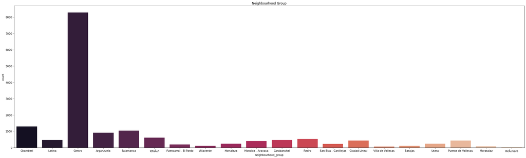

```python
sns.countplot(listings['neighbourhood_group'], palette="rocket")
fig = plt.gcf()
fig.set_size_inches(35,10)
warnings.filterwarnings("ignore")
plt.title('Neighbourhood Group')
```

The old city center (i.e. the neighbourhood called Centro) has almost 50% of the listings. That is, the center is extremely packed with Airbnbs.

### Pie plot of the room type

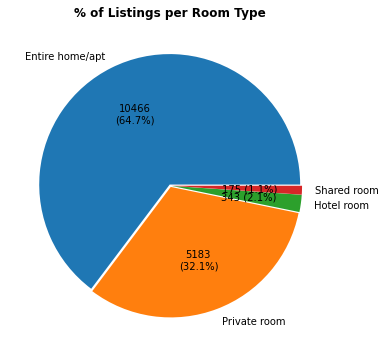

```python
fig, ax = plt.subplots(figsize=(6,6))
pie_data = (
    listings['room_type']
    .value_counts())
(pie_data
 .plot(kind='pie',
       autopct=lambda v: (
           '{}'.format(int(v/100*sum(pie_data))) +
           '\n' * int(v > 10) + ' ' * int(v <= 10) +
           '({:.1%})'.format(v/100)),
       explode=(0.01, ) * len(pie_data),
       ax=ax))
ax.set_ylabel('')
ax.set_title('% of Listings per Room Type', weight='bold')
plt.show()
```

We can already notice that despite Airbnb being originally created to share rooms, in Madrid more than 60% of the listings are actually about entire homes or apartments or even hotel rooms, while private and shared rooms make less than 40%. This is already an alarming piece of information.

#### Room type per neighbourhood

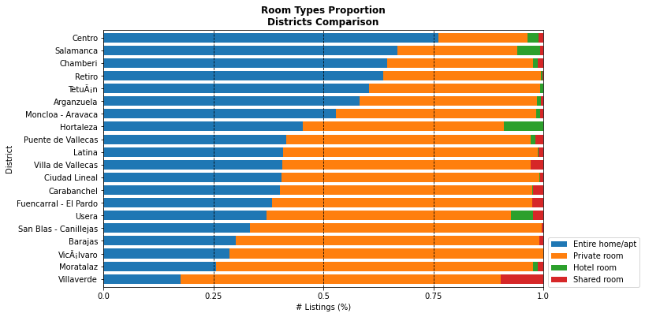

```python
fig, ax = plt.subplots(figsize=(10, 6))

barplot_data = (
    listings
    .groupby(['neighbourhood_group', 'room_type'])
    .size()
    .unstack('room_type')
    .fillna(0)
    .apply(lambda row: row / row.sum(), axis=1)
    .sort_values('Entire home/apt')
    .reindex(columns=listings['room_type'].value_counts().index))

barplot_data.plot(kind='barh', width=.75, stacked=True, ax=ax)

ax.set_xticks(np.linspace(0,1, 5))
ax.set_xticklabels(np.linspace(0,1, 5))
ax.grid(axis='x', c='k', ls='--')
ax.set_xlim(0,1)

ax.set_ylabel('District')
ax.set_xlabel('# Listings (%)')
ax.legend(loc=(1.01, 0))

ax.set_title('Room Types Proportion\nDistricts Comparison', weight='bold')

plt.show()
```

Here we see that nearly 76% of the listings in the Centro district are actually entire apartments. Absolutely amazing, especially if we consider how small the neighbourhood is. Centro is indeed the second smallest neighbourhood in the whole city behind Chamberi